# Introducción: Estructura avanzada

Sergio Nicasio-Arzeta

10/3/2020

# Objetos avanzados

## Clases

Por otro lado, las clases son la descripción del objeto (es el equivalente a los planos de una casa). El ambiente de R tiene cuatro sistemas de clases: **S3**, **S4**, **Reference class** y **R6**.

### Clase S3

Esta es la primer clase manejada por R y la más utilizada en programación. Carece de una definición predeterminada y se puede crear simplemente al añadir un atributo de clase con el comando `class()`:

```r
>     #   Elaboro un objeto que contiene un vector numerico sin clase definida
>
> Ob3 <- list(nombre="Ramiro",edad=36,estatura=1.68)
> Ob3
```

```
## $nombre
## [1] "Ramiro"
##
## $edad
## [1] 36
##
## $estatura
## [1] 1.68
```

```r
> str(Ob3)
```

```
## List of 3
##  $ nombre  : chr "Ramiro"
##  $ edad    : num 36
##  $ estatura: num 1.68
```

```r
>
>     #   Ahora declaro su clase con el comando "class()"
>
> class(Ob3) <- "estatura"
> Ob3     #   listo, ahora tenemos un objeto de la clase "estatura"
```

```
## $nombre
## [1] "Ramiro"
##
## $edad
## [1] 36
##
## $estatura
## [1] 1.68
##
## attr(,"class")
## [1] "estatura"
```

```r
> str(Ob3)
```

```
## List of 3
##  $ nombre  : chr "Ramiro"
##  $ edad    : num 36
##  $ estatura: num 1.68
##  - attr(*, "class")= chr "estatura"
```

```r
> #c(1.65,1.61,1.72,1.84,1.55,1.63,1.67,1.68,1.68,1.65,1.64,1.71)
```

Contrario a otros lenguajes de programación orientados a objetos (C++ o Python), donde hay definiciones de clase formales y los objetos tienen atributos y métodos definidos; el sistema S3 de R permite convertor la clase de un objeto de forma *ad hoc*. A su vez, permite nombrar objetos que contienen distinta información con la misma clase.

#### Vectores atómicos S3

Existen asignaciones de clase S3 para vectores atómicos que modifican la información que almacenan. Estos son los cuatro vectores atómicos S3 más importantes en R:

- **Factores:** Variables categóricas que contienen un número establecido de *niveles*. Se almacenan en vectores `factor`.
- **Fecha:** Registros de fechas con resolución de día. Se almacenan en vetores `Date`.
- **Fecha-hora:** Registros de fecha con resolución de segundos. Se almacenan en vectores `POSIXvc`.
- **Duraciones:** Registros de tiempo. Se almacenan en vectores `difftime`.

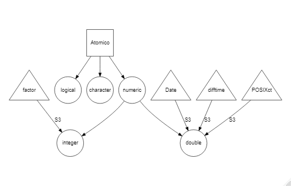

##### Factores

Los factores son vectores que contienen valores predefinidos y se usan para almacenar información categórica. Los factores se construyen sobre un vector numérico discreto (integer) y presenta dos atributos: una clase *factor* que lo diferencía de otros vectores discretos y los *niveles*, que definen el grupo de valores permitidos. Para generar un factor, se emplea el comando `factor()`:

```r
>     #   Elaboracion de un factor
>
> x <- factor(c("a", "b", "b", "a"))
> x   #   A pesar haber cuatro valores, solo observamos dos niveles
```

```
## [1] a b b a
## Levels: a b
```

```r
>
>     #   Al analizar el tipo de vector atomico al que corresponde, vemos que se lee como un integer
>
> typeof(x)
```

```
## [1] "integer"
```

```r
>
>     #   Por ultimo, veamos los atributos asigandos a este vector
>
> attributes(x)
```

```
## $levels
## [1] "a" "b"
##
## $class
## [1] "factor"
```

Los factores son útiles cuando la representación de los valores no es completa en un grupo de datos.

```r
>     #   Elaboramos un vector de caracteres
>
> sex_char <- c("m", "m", "m")
>
>     #   Establecemos los niveles existentes dentro del comando "factor()"
>
> sex_factor <- factor(sex_char, levels = c("m", "f"))
>
>     #   Observamos la frecuencia de observaciones con el comando "table()"
>
> table(sex_char)
## sex_char
## m
## 3
>
> table(sex_factor)
## sex_factor
## m f
## 3 0
```

También podemos generar factores ordenados, que son el equivalente a las variables cualitativas ordinales. Esto se logra con el comando `ordered()`

```r
> niv_eco <- ordered(c("bajo", "bajo", "alto", "medio"), levels = c("bajo", "medio", "alto"))
> niv_eco
```

```
## [1] bajo  bajo  alto  medio
## Levels: bajo < medio < alto
```

##### Fechas

Por su parte, las fechas se construyen a partir de vectores numéricos continuos (double) y solo presentan la clase `Date`.

```r
>     #   Generamos un objeto de fecha usando la fecha registrada en el sistema con "Sys.Date()"
>
> today <- Sys.Date()
> today
```

```
## [1] "2020-03-10"
```

```r
> str(today)
```

```
##  Date[1:1], format: "2020-03-10"
```

```r
>
>     #   Al analizar el tipo de vector atomico al que corresponde, vemos que se lee como un double
>
> typeof(today)
```

```
## [1] "double"
```

```r
>
>     #   Por ultimo, veamos los atributos asigandos a este vector
>
> attributes(today)
```

```
## $class
## [1] "Date"
```

```r
>
>     #   Ahora elaboremos un vector de fecha con nuestra fecha de nacimiento
>
> nacimiento <- as.Date("1985-10-08")
> nacimiento
```

```
## [1] "1985-10-08"
```

```r
>
>     #   El valor double representa el numero de dias a partir de 1970-01-01 (Inicio de la epoca UNIX o POSIX time)
> unclass(nacimiento)
```

```
## [1] 5759
```

##### Fecha-hora

```r
>     #   Formato "POSIXct"
>
> nac_ct <- as.POSIXct("1985-10-08 7:00", tz = "UTC")
> nac_ct
```

```
## [1] "1985-10-08 07:00:00 UTC"
```

```r
> typeof(nac_ct)
```

```
## [1] "double"
```

```r
> attributes(nac_ct)
```

```
## $class
## [1] "POSIXct" "POSIXt"
##
## $tzone
## [1] "UTC"
```

```r
> unclass(nac_ct)
```

```
## [1] 497602800
## attr(,"tzone")
## [1] "UTC"
```

```r
>
>     #   Formato "PISIXlt"
>
> nac_lt <- as.POSIXlt("1985-10-08 7:00", tz = "UTC")
> nac_lt$sec
```

```
## [1] 0
```

```r
> nac_lt$min
```

```
## [1] 0
```

```r
> nac_lt$hour
```

```
## [1] 7
```

```r
> nac_lt$mday
```

```
## [1] 8
```

```r
> nac_lt$mon
```

```
## [1] 9
```

```r
> nac_lt$year
```

```
## [1] 85
```

```r
> nac_lt$wday
```

```
## [1] 2
```

```r
> nac_lt$yday
```

```
## [1] 280
```

```r
> nac_lt$isdst
```

```
## [1] 0
```

```r
>
> typeof(nac_lt)
```

```
## [1] "list"
```

```r
> typeof(nac_lt$sec)
```

```
## [1] "double"
```

```r
>
> attributes(nac_lt)
```

```
## $names
## [1] "sec"   "min"   "hour"  "mday"  "mon"   "year"  "wday"  "yday"  "isdst"
##
## $class
## [1] "POSIXlt" "POSIXt"
##
## $tzone
## [1] "UTC"
```

El atributo `tzone` del comando `structure()` controla el formato de la fecha, más no el instante de tiempo representado.

```r
> nac_ct
```

```
## [1] "1985-10-08 07:00:00 UTC"
```

```r
>
>     #   Ahora veamos distintos formatos dependiendo de la zona horaria
>
> structure(nac_ct, tzone = "Asia/Tokyo")
```

```
## [1] "1985-10-08 16:00:00 JST"
```

```r
> structure(nac_ct, tzone = "America/New_York")
```

```
## [1] "1985-10-08 03:00:00 EDT"
```

```r
> structure(nac_ct, tzone = "Australia/Lord_Howe")
```

```
## [1] "1985-10-08 17:30:00 +1030"
```

```r
> structure(nac_ct, tzone = "Europe/Paris")
```

```
## [1] "1985-10-08 08:00:00 CET"
```

##### Duraciones

Por último, las duraciones representan el tiempo entre pares de fechas o fechas-hora. El resultado se almacena como tiempos de diferencia. Estos tiempos de diferencia se construyen sobre vectores double y el atributo `units` determina como se debe interpretar el valor.

```r
>
> dur_sem <- as.difftime(4, units = "weeks")
> dur_sem
## Time difference of 4 weeks
> typeof(dur_sem)
```

```
## [1] "double"
```

```r
> attributes(dur_sem)
```

```
## $class
## [1] "difftime"
##
## $units
## [1] "weeks"
```

```r
>
> dur_dia <- as.difftime(8, units = "days")
> dur_dia
## Time difference of 8 days
> typeof(dur_dia)
```

```
## [1] "double"
```

```r
> attributes(dur_dia)
```

```
## $class
## [1] "difftime"
##
## $units
## [1] "days"
```

```r
>
>     #   Analicemos la duracion del curso
>
> f1 <- as.POSIXct("2020-03-10 16:00", tz = "America/Mexico_City")    #   Inicio
> f2 <- as.POSIXct("2020-04-02 18:00", tz = "America/Mexico_City")    #   Final
>
> duracion <- f2-f1
> duracion
## Time difference of 23.08333 days
> attributes(duracion)
```

```
## $class
## [1] "difftime"
##
## $units
## [1] "days"
```

#### Vectores lista S3

Los dos principales objetos S3 que se elaboran a partir de listas son las tablas (`data.frame`) y los tibbles.

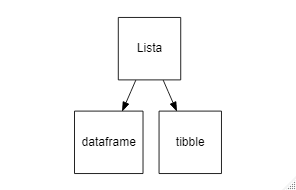

##### Tablas

Las tablas son de los objetos más comunes en R para el análisis de datos y consiste en una lista de vectores con atributos `names` (para columnas) y `row.names` (para filas) y la clase `data.frame`. A diferencia de las listas, la longitud de los vectores del `data.frame` debe ser la misma, resultando en una estructura rectangular que comparte las propiedades de las matrices y las listas.

Además, una tabla tiene:

- `rownames()` (nombre de filas)
- `colnames()`/`names()` (nombre de columnas)
- `nrow()` (número de filas)
- `ncol()`/`length()` (número de columnas)

```r
> df1 <- data.frame(x = 1:3, y = letters[1:3])
> df1
```

```
##   x y
## 1 1 a
## 2 2 b
## 3 3 c
```

```r
> str(df1)
```

```
## 'data.frame':    3 obs. of  2 variables:
##  $ x: int  1 2 3
##  $ y: Factor w/ 3 levels "a","b","c": 1 2 3
```

```r
> typeof(df1)
```

```
## [1] "list"
```

```r
> attributes(df1)
```

```
## $names
## [1] "x" "y"
##
## $class
## [1] "data.frame"
##
## $row.names
## [1] 1 2 3
```

```r
>
> rownames(df1)
```

```
## [1] "1" "2" "3"
```

```r
> colnames(df1)
```

```
## [1] "x" "y"
```

```r
> names(df1)
```

```
## [1] "x" "y"
```

```r
> nrow(df1)
```

```
## [1] 3
```

```r
> ncol(df1)
```

```
## [1] 2
```

```r
> length(df1)
```

```
## [1] 2
```

##### Tibbles

Los tibbles son una versión moderna de las tablas creadas en 2018. Algunas de sus ventajas sobre los `data.frame` son las siguientes:

- No cambia el tipo de variable (los data.frame automáticamente asignan las variables de texto como factores)

```r
>     #   Los data.frame asignan automaticamente la clase "factor" a la variable con caracteres
>
> x <- data.frame(x = letters)
> x
```

```
##    x
## 1  a
## 2  b
## 3  c
## 4  d
## 5  e
## 6  f
## 7  g
## 8  h
## 9  i
## 10 j
## 11 k
## 12 l
## 13 m
## 14 n
## 15 o
## 16 p
## 17 q
## 18 r
## 19 s
## 20 t
## 21 u
## 22 v
## 23 w
## 24 x
## 25 y
## 26 z
```

```r
> str(x)
```

```
## 'data.frame':    26 obs. of  1 variable:
##  $ x: Factor w/ 26 levels "a","b","c","d",..: 1 2 3 4 5 6 7 8 9 10 ...
```

```r
>
>     #   Los tibble no transforman las variables de caracteres a factores
>
> require(tibble)
>
> x <- tibble(x = letters)
> x
```

```
## # A tibble: 26 x 1
##    x
##    <chr>
##  1 a
##  2 b
##  3 c
##  4 d
##  5 e
##  6 f
##  7 g
##  8 h
##  9 i
## 10 j
## # ... with 16 more rows
```

```r
> str(x)
```

```
## Classes 'tbl_df', 'tbl' and 'data.frame':    26 obs. of  1 variable:
##  $ x: chr  "a" "b" "c" "d" ...
```

```r
>
>     #   Esto facilita su uso con columnas de listas:
>
> tibble(x = 1:3, y = list(1:5, 1:10, 1:20))
```

```
## # A tibble: 3 x 2
##       x y
##   <int> <list>
## 1     1 <int [5]>
## 2     2 <int [10]>
## 3     3 <int [20]>
```

- No ajusta el nombre de las variables

```r
>     #   Los titulos de las columnas en data.frame no pueden llevar espacios
>
> names(data.frame(`crazy name` = 1))
```

```
## [1] "crazy.name"
```

```r
>
>     #   Por su parte, los titulos de columna de un tibble si soportan los espacios
>
> names(tibble(`crazy name` = 1))
```

```
## [1] "crazy name"
```

- Evalúa los argumentos de forma secuencial

```r
> tibble(x = 1:5, y = x ^ 2)
```

```
## # A tibble: 5 x 2
##       x     y
##   <int> <dbl>
## 1     1     1
## 2     2     4
## 3     3     9
## 4     4    16
## 5     5    25
```

- No emplea el comando `row.names()`
- Mientras `data.frame()` recicla las columnas que son multiplo de la dimension de la columna más larga, los tibbles solamente reciclan los vectores de dimension uno

```r
> data.frame(x = 1:4, y = 1:2)
```

```
##   x y
## 1 1 1
## 2 2 2
## 3 3 1
## 4 4 2
```

```r
> data.frame(x = 1:4, y = 1:3)
```

```
## Error in data.frame(x = 1:4, y = 1:3): arguments imply differing number of rows: 4, 3
```

```r
>
> tibble(x = 1:4, y = 1)
```

```
## # A tibble: 4 x 2
##       x     y
##   <int> <dbl>
## 1     1     1
## 2     2     1
## 3     3     1
## 4     4     1
```

```r
> tibble(x = 1:4, y = 1:2)
```

```
## Error: Tibble columns must have consistent lengths, only values of length one are recycled:
## * Length 2: Column `y`
## * Length 4: Column `x`
```

### Clase S4

Esta clase de objeto tiene una estructura formalmente definida. Esto permite controlar la forma en que creamos objetos. La clase de los objetos se define con el comando `setclass()` y los objetos se crean con el comando `new()`:

```r
> setClass("personal",slots = list(nombre="character",edad="numeric",estatura="numeric"))
> Ob4 <- new("personal", nombre="Ramiro",edad=36,estatura=1.68)
> Ob4
## An object of class "personal"
## Slot "nombre":
## [1] "Ramiro"
##
## Slot "edad":
## [1] 36
##
## Slot "estatura":
## [1] 1.68
```

Podemos verificar si el objeto es de la clase S4 con el comando `isS4()`:

```r
> isS4(Ob4)
```

```
## [1] TRUE
```

### Clase referencia

Este tipo de clase es último incorporado a R respecto a las clases S3 y S4. Sus características son más similares a las clases usadas en otros lenguajes de programación orientados a objetos. El comando `setRefClass()` da como resultado una función generadora de objetos con clase de referencia:

```r
> personal <- setRefClass(Class = "personal",
+                         fields = list(nombre="character",edad="numeric",estatura="numeric"))
>     #   Ahora personal() es una funcion generadora que puede crear objetos nuevos
```